# Лабораторна робота №5. Випадок з двома вибірками. Побудова регресійних моделей

Шулещенко Артем Вадимович

## Мета роботи

Побудувати модель **парної регресії** між змінними $X$ та $Y$ за даними з Excel-файлу **Варианты1-17.xls**, оцінити параметри моделі, перевірити її адекватність і виконати аналіз залишків.

## Вибір змінних для варіанту 12

Для **варіанту 12** використовуються колонки:

- $X$ = **Col_13**
- $Y$ = **Col_38**

(якщо в Excel інші назви, нижче вони автоматично перейменуються в `Col_1..Col_k` за позиціями)

## Пакети

Для імпорту даних використовуємо **readxl**.

```r
pkgs <- c("readxl", "dplyr", "ggplot2", "broom", "lmtest", "tibble")

to_install <- pkgs[!pkgs %in% rownames(installed.packages())]
if (length(to_install) > 0) install.packages(to_install)

library(readxl)
library(dplyr)
library(ggplot2)
library(broom)
library(lmtest)
library(tibble)
```

## Імпорт даних з Excel

```r
file_path <- "Варианты1-17.xls"
stopifnot(file.exists(file_path))

raw_data <- read_excel(file_path, sheet = 1)

dim(raw_data)
```

```
## [1] 100  41
```

```r
names(raw_data)
```

```
##  [1] "N"  "2"  "3"  "4"  "5"  "6"  "7"  "8"  "9"  "10" "11" "12" "13" "14" "15"
## [16] "16" "17" "18" "19" "20" "21" "22" "23" "24" "25" "26" "27" "28" "29" "30"
## [31] "31" "32" "33" "34" "35" "36" "37" "38" "39" "40" "41"
```

```r
head(raw_data, 3)
```

| N | 2 | 3 | 4 | 5 | 6 | 7 | 8 | 9 | 10 | 11 | 12 | 13 | 14 | 15 | 16 | 17 | 18 | 19 | 20 | 21 | 22 | 23 | 24 | 25 | 26 | 27 | 28 | 29 | 30 | … |
| --- | --- | --- | --- | --- | --- | --- | --- | --- | --- | --- | --- | --- | --- | --- | --- | --- | --- | --- | --- | --- | --- | --- | --- | --- | --- | --- | --- | --- | --- | --- |
| 1 | 8.17 | 9.42 | 2.45 | 1.14 | 9.03 | 5.06 | -0.42 | 0.94 | 16.23 | 1.07 | 3.81 | 4.31 | -5.02 | 12.54 | 12.84 | 15.31 | 3.44 | 13.12 | 4.94 | 13.94 | 0.01 | 0.54 | 0.44 | 1.14 | 0.25 | 172.9876 | 2775.6128 | 82.60423 | 38.994440 | … |
| 2 | 5.74 | 8.82 | 3.56 | 1.15 | 5.98 | 5.67 | -3.79 | -3.37 | 13.49 | 1.22 | 4.39 | 3.07 | -5.34 | 13.83 | 6.83 | 13.71 | -1.44 | 14.34 | 6.30 | 9.63 | 1.12 | 0.08 | 0.74 | 0.28 | 0.20 | 163.7079 | 1590.6198 | 106.45090 | -4.591375 | … |
| 3 | 7.89 | 5.73 | 2.67 | -2.85 | 6.43 | 3.04 | 2.16 | -0.98 | 15.08 | 1.41 | 0.74 | 0.43 | -4.90 | 9.98 | 12.38 | 17.39 | -0.72 | 9.07 | 8.18 | 12.02 | 3.95 | 1.13 | 0.84 | 0.06 | 0.38 | 298.4242 | 852.1153 | 82.99973 | 222.827125 | … |

## Формування даних X та Y (варіант 12)

Щоб уникнути конфліктів імен, використовуємо назву **df_data**.

```r
if (!all(grepl("^Col_\\d+$", names(raw_data)))) {
  names(raw_data) <- paste0("Col_", seq_along(raw_data))
}

x_col <- "Col_13"
y_col <- "Col_38"

df_data <- raw_data %>%
  transmute(
    X = as.numeric(.data[[x_col]]),
    Y = as.numeric(.data[[y_col]])
  ) %>%
  filter(!is.na(X), !is.na(Y))

stopifnot(is.data.frame(df_data))
stopifnot(all(c("X","Y") %in% names(df_data)))

summary(df_data)
```

```
##        X               Y
##  Min.   :0.010   Min.   :-9954.4
##  1st Qu.:0.290   1st Qu.:-3896.3
##  Median :0.800   Median :  677.2
##  Mean   :1.241   Mean   :  879.3
##  3rd Qu.:1.683   3rd Qu.: 5025.4
##  Max.   :7.750   Max.   :67239.1
```

## Описові статистики та кореляція

```r
desc <- df_data %>%
  summarise(
    n = n(),
    mean_X = mean(X), sd_X = sd(X),
    mean_Y = mean(Y), sd_Y = sd(Y),
    cor_XY = cor(X, Y)
  )

desc
```

| n | mean_X | sd_X | mean_Y | sd_Y | cor_XY |
| --- | --- | --- | --- | --- | --- |
| 100 | 1.241 | 1.331526 | 879.2574 | 8877.059 | 0.5525428 |

## Діаграма розсіювання

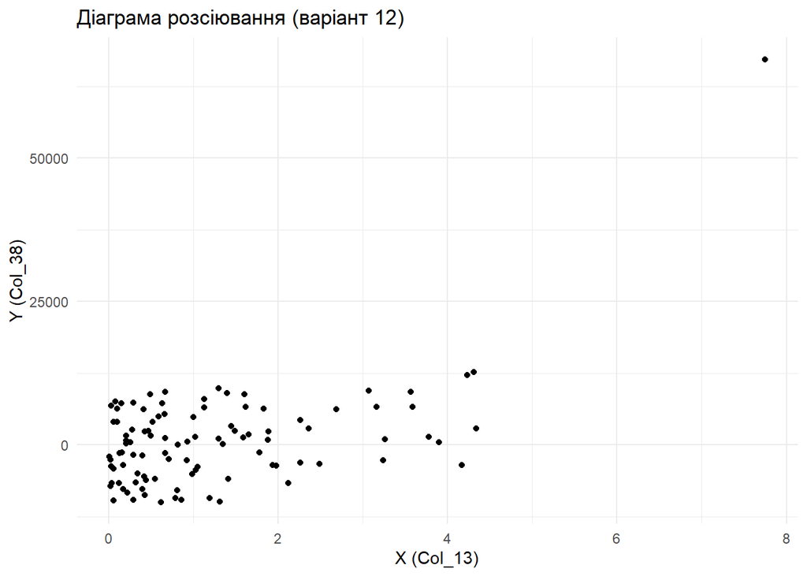

```r
ggplot(df_data, aes(x = X, y = Y)) +
  geom_point() +
  labs(
    title = "Діаграма розсіювання (варіант 12)",
    x = "X (Col_13)",
    y = "Y (Col_38)"
  ) +
  theme_minimal()
```

## Побудова регресійних моделей

```r
m1 <- lm(Y ~ X, data = df_data)
m2 <- lm(Y ~ poly(X, 2, raw = TRUE), data = df_data)

summary(m1)
```

```
##
## Call:
## lm(formula = Y ~ X, data = df_data)
##
## Residuals:
##    Min     1Q Median     3Q    Max
## -15177  -4547   -214   4343  42383
##
## Coefficients:
##             Estimate Std. Error t value Pr(>|t|)
## (Intercept)  -3692.2     1018.9  -3.624 0.000463 ***
## X             3683.7      561.3   6.563 2.52e-09 ***
## ---
## Signif. codes:  0 '***' 0.001 '**' 0.01 '*' 0.05 '.' 0.1 ' ' 1
##
## Residual standard error: 7437 on 98 degrees of freedom
## Multiple R-squared:  0.3053, Adjusted R-squared:  0.2982
## F-statistic: 43.07 on 1 and 98 DF,  p-value: 2.52e-09
```

```r
summary(m2)
```

```
##
## Call:
## lm(formula = Y ~ poly(X, 2, raw = TRUE), data = df_data)
##
## Residuals:
##      Min       1Q   Median       3Q      Max
## -14408.3  -4511.7    525.9   4050.3  11468.8
##
## Coefficients:
##                         Estimate Std. Error t value Pr(>|t|)
## (Intercept)                453.1      982.1   0.461  0.64556
## poly(X, 2, raw = TRUE)1  -3446.7     1047.2  -3.291  0.00139 **
## poly(X, 2, raw = TRUE)2   1427.3      189.5   7.533  2.6e-11 ***
## ---
## Signif. codes:  0 '***' 0.001 '**' 0.01 '*' 0.05 '.' 0.1 ' ' 1
##
## Residual standard error: 5937 on 97 degrees of freedom
## Multiple R-squared:  0.5617, Adjusted R-squared:  0.5527
## F-statistic: 62.16 on 2 and 97 DF,  p-value: < 2.2e-16
```

### Порівняння моделей (AIC та Adjusted R²)

```r
cmp <- bind_rows(
  glance(m1) %>% mutate(model = "Лінійна: Y ~ X"),
  glance(m2) %>% mutate(model = "Квадратична: Y ~ X + X^2")
) %>%
  select(model, r.squared, adj.r.squared, AIC, BIC, sigma, p.value)

cmp
```

| model | r.squared | adj.r.squared | AIC | BIC | sigma | p.value |
| --- | --- | --- | --- | --- | --- | --- |
| Лінійна: Y ~ X | 0.3053035 | 0.2982148 | 2070.600 | 2078.415 | 7436.545 | 2.520165e-09 |
| Квадратична: Y ~ X + X^2 | 0.5617211 | 0.5526845 | 2026.538 | 2036.958 | 5937.124 | 4.215995e-18 |

### Вибір найкращої моделі

```r
best_name <- cmp$model[which.min(cmp$AIC)]
best_model <- if (best_name == "Лінійна: Y ~ X") m1 else m2

best_name
```

```
## [1] "Квадратична: Y ~ X + X^2"
```

```r
summary(best_model)
```

```
##
## Call:
## lm(formula = Y ~ poly(X, 2, raw = TRUE), data = df_data)
##
## Residuals:
##      Min       1Q   Median       3Q      Max
## -14408.3  -4511.7    525.9   4050.3  11468.8
##
## Coefficients:
##                         Estimate Std. Error t value Pr(>|t|)
## (Intercept)                453.1      982.1   0.461  0.64556
## poly(X, 2, raw = TRUE)1  -3446.7     1047.2  -3.291  0.00139 **
## poly(X, 2, raw = TRUE)2   1427.3      189.5   7.533  2.6e-11 ***
## ---
## Signif. codes:  0 '***' 0.001 '**' 0.01 '*' 0.05 '.' 0.1 ' ' 1
##
## Residual standard error: 5937 on 97 degrees of freedom
## Multiple R-squared:  0.5617, Adjusted R-squared:  0.5527
## F-statistic: 62.16 on 2 and 97 DF,  p-value: < 2.2e-16
```

## Візуалізація регресії (виправлено без inline-if у formula)

> Помилка `unexpected token 'y'` часто виникає через некоректне копіювання або через те, що в `aes()` поставили `-` замість `=`. Нижче — найбільш надійний варіант: окремі гілки `if/else`, і в `aes()` **обов’язково `x = X`, `y = Y`**.

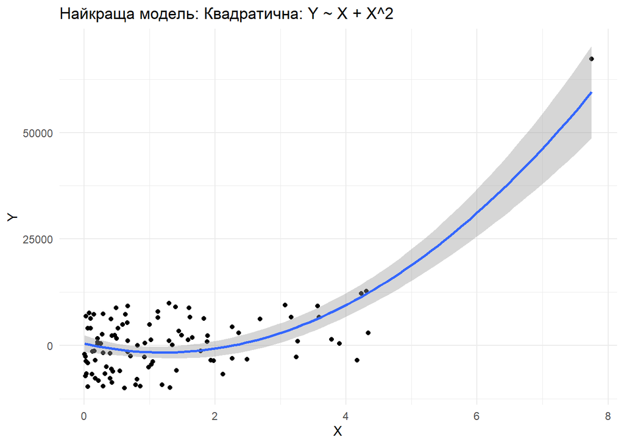

```r
p <- ggplot(df_data, aes(x = X, y = Y)) +
  geom_point()

if (best_name == "Лінійна: Y ~ X") {
  p <- p + geom_smooth(method = "lm", formula = y ~ x, se = TRUE)
} else {
  p <- p + geom_smooth(method = "lm", formula = y ~ poly(x, 2, raw = TRUE), se = TRUE)
}

p +
  labs(
    title = paste0("Найкраща модель: ", best_name),
    x = "X",
    y = "Y"
  ) +
  theme_minimal()
```

## Діагностика моделі (аналіз залишків)

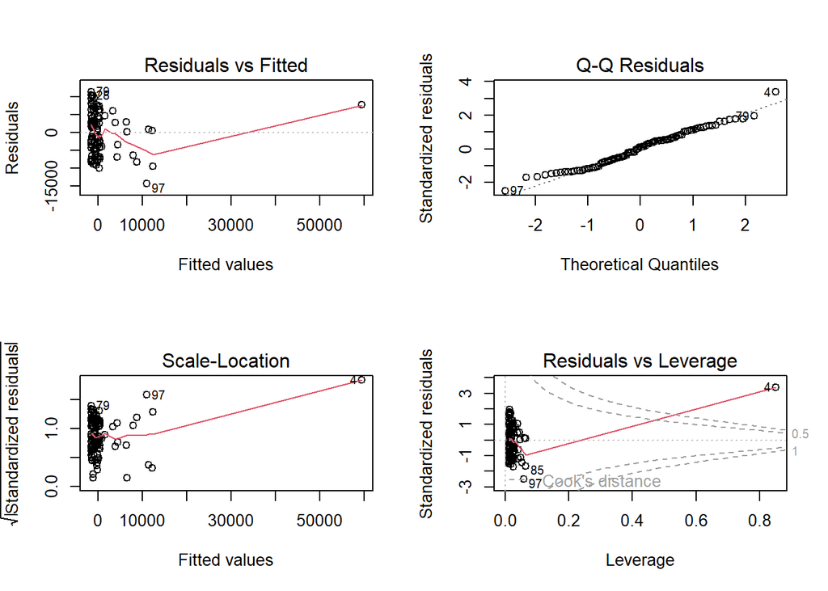

```r
par(mfrow = c(2, 2))
plot(best_model)
```

```r
par(mfrow = c(1, 1))
```

### Тести для залишків

```r
res <- residuals(best_model)

sh <- shapiro.test(res)
bp <- bptest(best_model)

sh
```

```
##
##  Shapiro-Wilk normality test
##
## data:  res
## W = 0.97426, p-value = 0.04719
```

```r
bp
```

```
##
##  studentized Breusch-Pagan test
##
## data:  best_model
## BP = 1.6273, df = 2, p-value = 0.4432
```

## Рівняння регресії

```r
coef_best <- coef(best_model)

eq <- if (best_name == "Лінійна: Y ~ X") {
  paste0("Y = ", round(coef_best[1], 4), " + ", round(coef_best[2], 4), "·X")
} else {
  paste0("Y = ", round(coef_best[1], 4), " + ", round(coef_best[2], 4), "·X + ", round(coef_best[3], 4), "·X^2")
}

eq
```

```
## [1] "Y = 453.1275 + -3446.7108·X + 1427.3301·X^2"
```

## Приклад прогнозування

```r
newdata <- data.frame(X = seq(min(df_data$X), max(df_data$X), length.out = 5))
pred <- predict(best_model, newdata = newdata, interval = "confidence")
cbind(newdata, pred)
```

|  | X | fit | lwr | upr |
| --- | --- | --- | --- | --- |
| 1 | 0.010 | 418.8031 | -1514.962 | 2352.5682 |
| 2 | 1.945 | -851.0995 | -2605.575 | 903.3764 |
| 3 | 3.880 | 8567.4881 | 5887.054 | 11247.9224 |
| 4 | 5.815 | 28674.5660 | 23550.551 | 33798.5809 |
| 5 | 7.750 | 59470.1340 | 48604.317 | 70335.9512 |

## Висновки

1. Дані імпортовано з файлу **Варианты1-17.xls** за допомогою пакета `readxl`. Для варіанту 12 сформовано пару змінних $X=$ `Col_13` та $Y=$ `Col_38`.
2. Побудовано дві моделі парної регресії (лінійну та квадратичну) та виконано їх порівняння за критерієм **AIC** і показником **Adjusted R²**.
3. Обрано найкращу модель: **Квадратична: Y ~ X + X^2**. Для неї $R^2 =$ **0.5617**, $Adj.\ R^2 =$ **0.5527**.
4. Проведено діагностику залишків: тест Shapiro–Wilk дав p-value **0.04719**, а тест Breusch–Pagan — p-value **0.4432**. На рівні значущості 0.05 висновок робиться шляхом порівняння p-value з $\alpha$.
5. Остаточне рівняння регресії: **Y = 453.1275 + -3446.7108·X + 1427.3301·X^2**. На його основі виконано приклад прогнозування $Y$ для заданих значень $X$.